# Coxon_HW1

Victoria Coxon

September 3, 2015

# PART A - Load Gapminder Data

```r
gapminderData5Yr.data = read.delim(file="http://www.stat.ubc.ca/~jenny/notOcto/STAT545A/examples/gapminder/data/gapminderDataFiveYear.txt")
```

This function seems to handle the data set better; possibly because this function is not expecting a specific delimiters (ie. a , or ;).

I can use access to the data provided by this function to determine what the problem is at line/row 146.

```r
head(gapminderData5Yr.data)
```

```
##       country year      pop continent lifeExp gdpPercap
## 1 Afghanistan 1952  8425333      Asia  28.801  779.4453
## 2 Afghanistan 1957  9240934      Asia  30.332  820.8530
## 3 Afghanistan 1962 10267083      Asia  31.997  853.1007
## 4 Afghanistan 1967 11537966      Asia  34.020  836.1971
## 5 Afghanistan 1972 13079460      Asia  36.088  739.9811
## 6 Afghanistan 1977 14880372      Asia  38.438  786.1134
```

```r
dim(gapminderData5Yr.data)
```

```
## [1] 1704    6
```

```r
tail(gapminderData5Yr.data)
```

```
##       country year      pop continent lifeExp gdpPercap
## 1699 Zimbabwe 1982  7636524    Africa  60.363  788.8550
## 1700 Zimbabwe 1987  9216418    Africa  62.351  706.1573
## 1701 Zimbabwe 1992 10704340    Africa  60.377  693.4208
## 1702 Zimbabwe 1997 11404948    Africa  46.809  792.4500
## 1703 Zimbabwe 2002 11926563    Africa  39.989  672.0386
## 1704 Zimbabwe 2007 12311143    Africa  43.487  469.7093
```

```r
gapminderData5Yr.data[146,]
```

```
##                    country year     pop continent lifeExp gdpPercap
## 146 Bosnia and Herzegovina 1957 3076000    Europe   58.45  1353.989
```

Line 146 lists Bosnia and Herzegovina. This country name is much longer than both the Head and Tail countries.

I suspect the error has something to do with the length of this country’s name. *(They could have used a slash.)*

For the **read.table** function to work with this data set, I have to specify a delimiter argument because read.table does not expect a delimited file *(.csv(,)* or *.txt(tab))*, whereas **read.delim** does.

```r
gapminderData5Yr.data = read.table(file="http://www.stat.ubc.ca/~jenny/notOcto/STAT545A/examples/gapminder/data/gapminderDataFiveYear.txt", sep="\t",header=T)
```

With this code, I am telling R that the data set is a tab-delimited file and to keep the headers/variable names “TRUE”. Because this approach is a workaround the problem of comma separated value files or text *(tab separated)* files, there may still be problems with ‘weird’ translations into R.

Cote D’Ivoire presents such a case. It has an apostrophe; how does this approach handle it?

```r
gapminderData5Yr.data[grep("Cote",gapminderData5Yr.data$country),]
```

```
##                                                                country
## 361  Cote dIvoire\t1952\t2977019\tAfrica\t40.477\t1388.594732\nCote dIvoire
## 362   Cote dIvoire\t1962\t3832408\tAfrica\t44.93\t1728.869428\nCote dIvoire
## 363  Cote dIvoire\t1972\t6071696\tAfrica\t49.801\t2378.201111\nCote dIvoire
## 364  Cote dIvoire\t1982\t9025951\tAfrica\t53.983\t2602.710169\nCote dIvoire
## 365 Cote dIvoire\t1992\t12772596\tAfrica\t52.044\t1648.073791\nCote dIvoire
## 366 Cote dIvoire\t2002\t16252726\tAfrica\t46.832\t1648.800823\nCote dIvoire
##     year      pop continent lifeExp gdpPercap
## 361 1957  3300000    Africa  42.469  1500.896
## 362 1967  4744870    Africa  47.350  2052.050
## 363 1977  7459574    Africa  52.374  2517.737
## 364 1987 10761098    Africa  54.655  2156.956
## 365 1997 14625967    Africa  47.991  1786.265
## 366 2007 18013409    Africa  48.328  1544.750
```

Not so well… Let’s go back to the read.delim function…

```r
gapminderData5Yr.data = read.delim(file="http://www.stat.ubc.ca/~jenny/notOcto/STAT545A/examples/gapminder/data/gapminderDataFiveYear.txt", sep="\t",header=T)
```

Let’s see how this code handles Cote D’Ivoire…

```r
gapminderData5Yr.data[grep("Cote",gapminderData5Yr.data$country),]
```

```
##           country year      pop continent lifeExp gdpPercap
## 361 Cote d'Ivoire 1952  2977019    Africa  40.477  1388.595
## 362 Cote d'Ivoire 1957  3300000    Africa  42.469  1500.896
## 363 Cote d'Ivoire 1962  3832408    Africa  44.930  1728.869
## 364 Cote d'Ivoire 1967  4744870    Africa  47.350  2052.050
## 365 Cote d'Ivoire 1972  6071696    Africa  49.801  2378.201
## 366 Cote d'Ivoire 1977  7459574    Africa  52.374  2517.737
## 367 Cote d'Ivoire 1982  9025951    Africa  53.983  2602.710
## 368 Cote d'Ivoire 1987 10761098    Africa  54.655  2156.956
## 369 Cote d'Ivoire 1992 12772596    Africa  52.044  1648.074
## 370 Cote d'Ivoire 1997 14625967    Africa  47.991  1786.265
## 371 Cote d'Ivoire 2002 16252726    Africa  46.832  1648.801
## 372 Cote d'Ivoire 2007 18013409    Africa  48.328  1544.750
```

Note to self…ALWAYS look at the raw data to see if there are any possible translation problems and structure the R code to anticipate and deal with them.

# PART B - Data “Smell” Test

```r
class(gapminderData5Yr.data)
```

```
## [1] "data.frame"
```

The gapminderData5Yr is a data.frame.

```r
str(gapminderData5Yr.data)
```

```
## 'data.frame':    1704 obs. of  6 variables:
##  $ country  : Factor w/ 142 levels "Afghanistan",..: 1 1 1 1 1 1 1 1 1 1 ...
##  $ year     : int  1952 1957 1962 1967 1972 1977 1982 1987 1992 1997 ...
##  $ pop      : num  8425333 9240934 10267083 11537966 13079460 ...
##  $ continent: Factor w/ 5 levels "Africa","Americas",..: 3 3 3 3 3 3 3 3 3 3 ...
##  $ lifeExp  : num  28.8 30.3 32 34 36.1 ...
##  $ gdpPercap: num  779 821 853 836 740 ...
```

The str function allows us to examine the structure. But, I can also examine the data these ways.

```r
dim(gapminderData5Yr.data)
```

```
## [1] 1704    6
```

There are 1,704 observations (x) of 6 variables (y). Let’s check to make sure…

```r
nrow(gapminderData5Yr.data)
```

```
## [1] 1704
```

```r
ncol(gapminderData5Yr.data)
```

```
## [1] 6
```

I would use *nrow* or *ncol* if I wanted to create a new matrix with the dataset, but **dim** seems to do the job if you just want to see the dimensions of what you’re dealing with.

# PART C - Explore Individual Variables

```r
names(gapminderData5Yr.data)
```

```
## [1] "country"   "year"      "pop"       "continent" "lifeExp"   "gdpPercap"
```

Categorical Variables = country (+s are lots of variables), continent (+s are not a lot of variables)

Quantitative Variables = year, pop, lifeExp, and gdpPercap.

```r
unique(gapminderData5Yr.data$country)
```

```
##   [1] Afghanistan              Albania
##   [3] Algeria                  Angola
##   [5] Argentina                Australia
##   [7] Austria                  Bahrain
##   [9] Bangladesh               Belgium
##  [11] Benin                    Bolivia
##  [13] Bosnia and Herzegovina   Botswana
##  [15] Brazil                   Bulgaria
##  [17] Burkina Faso             Burundi
##  [19] Cambodia                 Cameroon
##  [21] Canada                   Central African Republic
##  [23] Chad                     Chile
##  [25] China                    Colombia
##  [27] Comoros                  Congo, Dem. Rep.
##  [29] Congo, Rep.              Costa Rica
```

[output cut: 57 more lines]

Great; now I have a location of where each country is in the data.

I want to know the level of well-being for people in the dataset. One measure of well-being is Per Capita GDP.

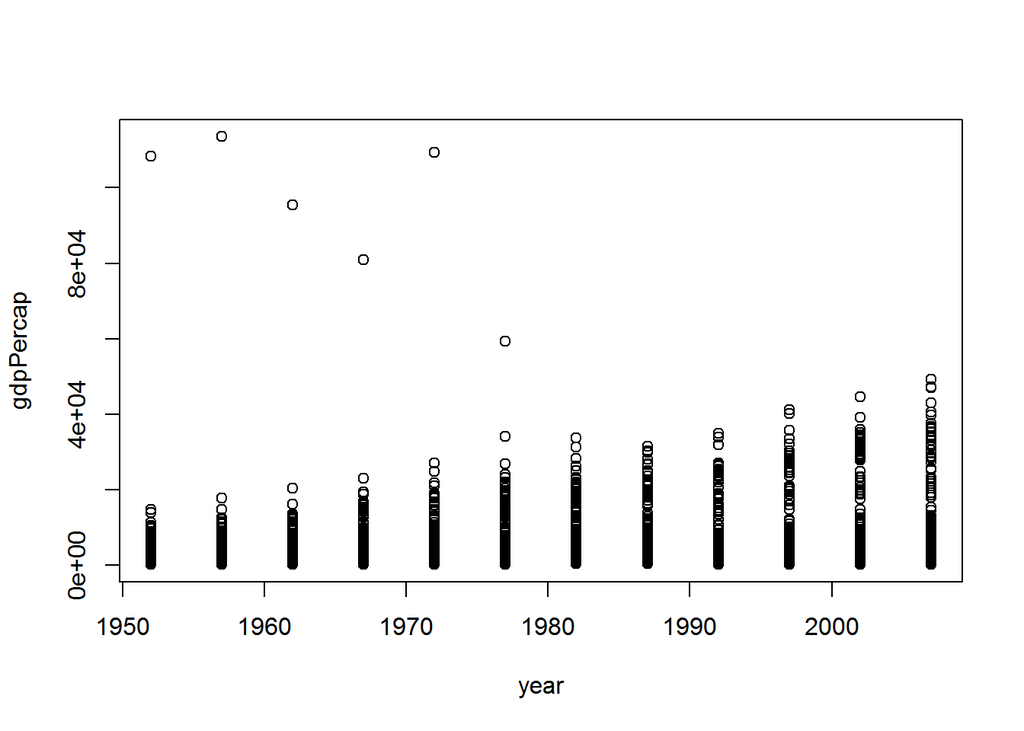

```r
plot(gdpPercap ~ year, gapminderData5Yr.data)
```

In general, it looks like there is an increasing amount of dispersion in Per Capita GDP. What is the summary statistics snapshot look like?

```r
summary(gapminderData5Yr.data$gdpPercap)
```

```
##     Min.  1st Qu.   Median     Mean  3rd Qu.     Max.
##    241.2   1202.0   3532.0   7215.0   9325.0 113500.0
```

Just from the summary statistics I can see that there is a large right skew in the data. As as aside, I wonder who is “dragging” the mean Per Capita GDP up?

Let’s confirm that my initial interpretation of the data is correct.

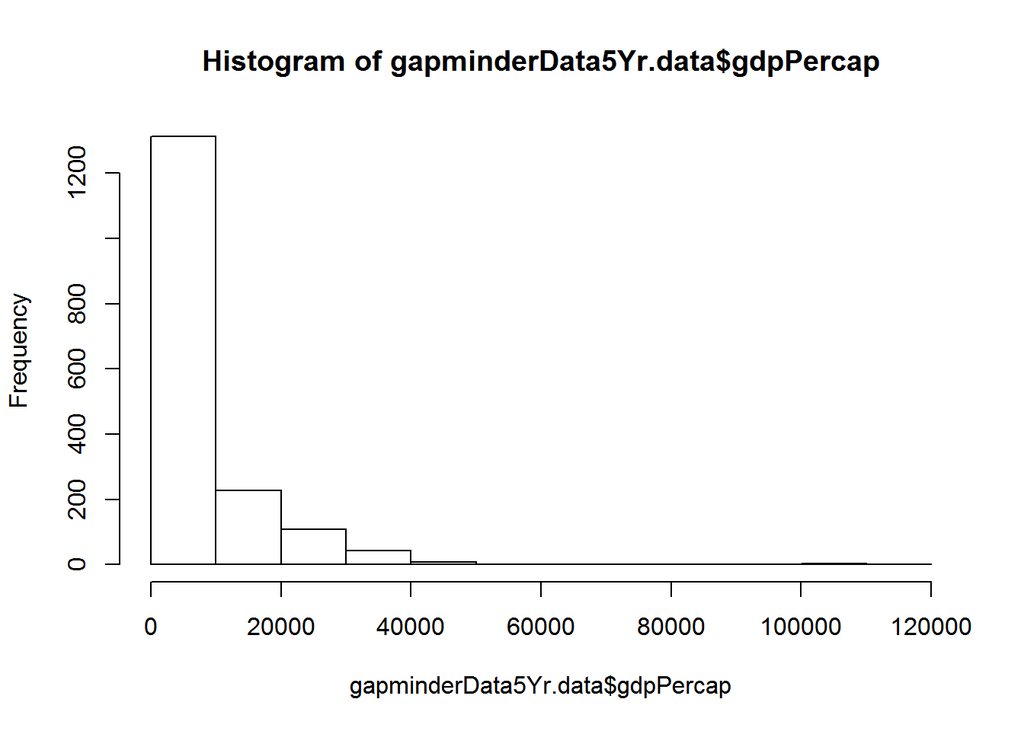

```r
hist(gapminderData5Yr.data$gdpPercap)
```

It is! Let’s look at another indicator of well-being; **lifeExp**.

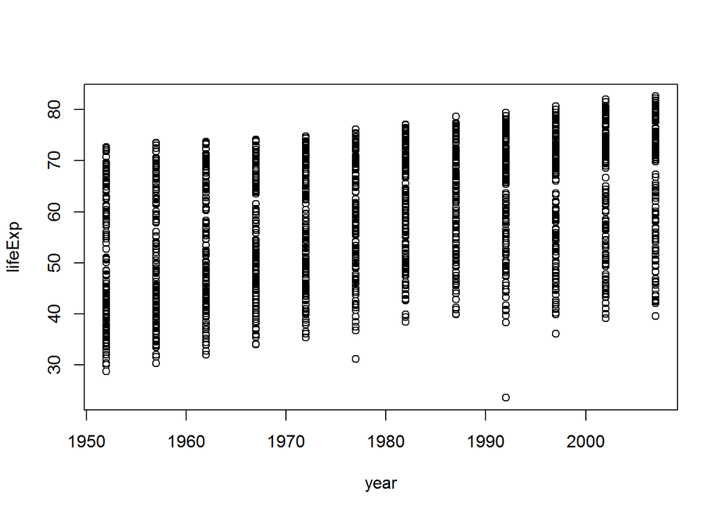

```r
plot(lifeExp ~ year, gapminderData5Yr.data)
```

I can see that life expectancy is generally going up. What else is going on?

```r
summary(gapminderData5Yr.data$lifeExp)
```

```
##    Min. 1st Qu.  Median    Mean 3rd Qu.    Max.
##   23.60   48.20   60.71   59.47   70.85   82.60
```

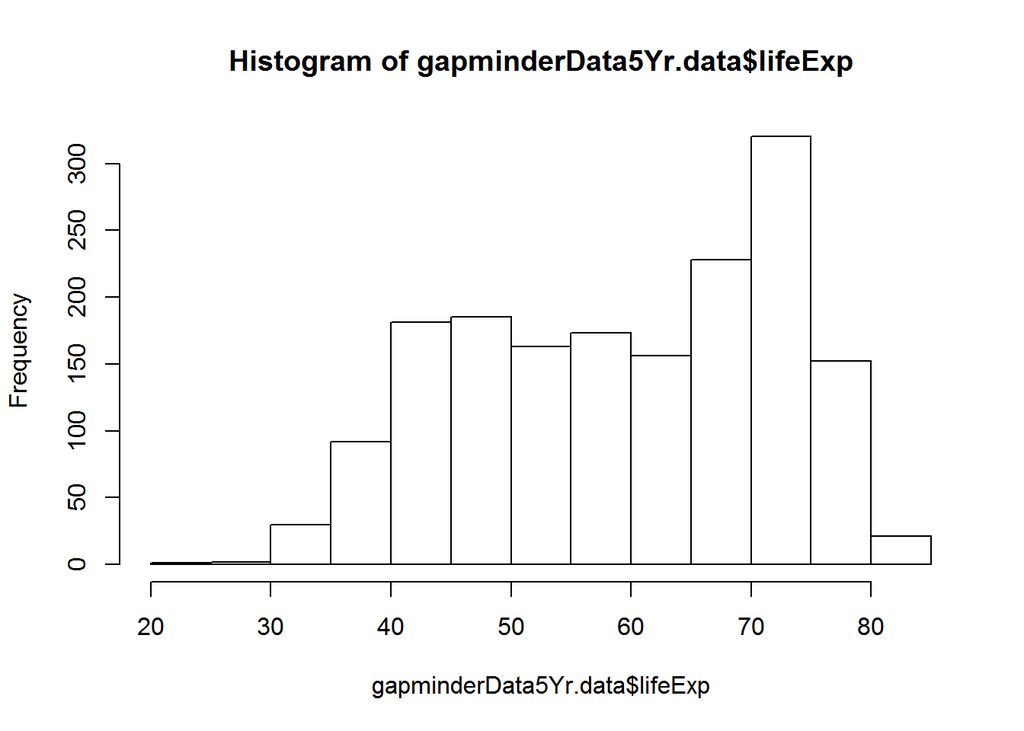

```r
hist(gapminderData5Yr.data$lifeExp)
```

This looks almost like the opposite mirror image of the previous histogram. A connection/relationship between Per Capita GDP and Life Expectancy? *(Yes, I know this has an obvious answer, but I am tryng to get a better understanding of how this works in R.)*

# PART D - Getting Down to Business

## TASK MENU

### 1. Get the max and min Per Capita GDP for all continents.

I need to “wrangle” this data, so I need dplyr. I also need to make charts and graphs so I need knitr to “knit” it all together.

```r
library(dplyr); library(knitr)
```

Using my prior knowledge about development policy and economics, I need to see the frequencies of the continent values in the data. It will make a difference in how I go about interpreting the data later.

```r
table(gapminderData5Yr.data$continent)
```

```
##
##   Africa Americas     Asia   Europe  Oceania
##      624      300      396      360       24
```

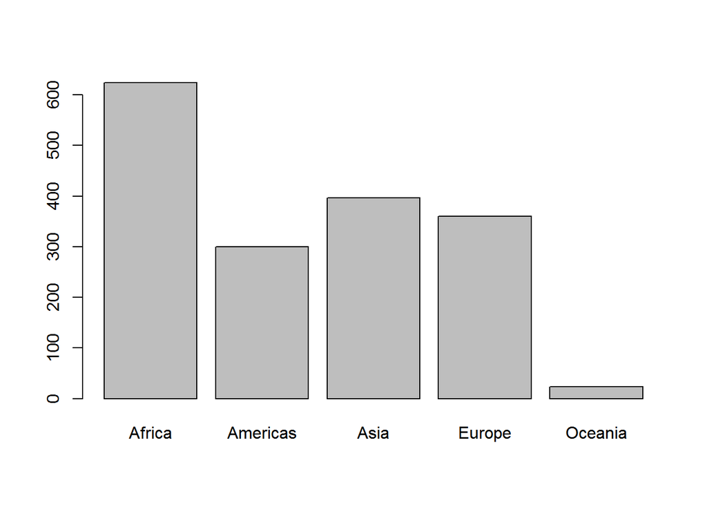

```r
barplot(table(gapminderData5Yr.data$continent))
```

I am going to sort the data by continents and then sort this new arrangement into showing me the max and min Per Capita GDP.

```r
gapminderData5Yr.data %>% group_by(continent) %>% summarise(min = min(gdpPercap), max = max(gdpPercap))
```

```
## Source: local data frame [5 x 3]
##
##   continent        min       max
## 1    Africa   241.1659  21951.21
## 2  Americas  1201.6372  42951.65
## 3      Asia   331.0000 113523.13
## 4    Europe   973.5332  49357.19
## 5   Oceania 10039.5956  34435.37
```

Let’s make a table of this information using the **kable** function.

```r
kable(gapminderData5Yr.data %>% group_by(continent) %>% summarise(min = min(gdpPercap), max = max(gdpPercap)))
```

| continent | min | max |
| --- | --- | --- |
| Africa | 241.1659 | 21951.21 |
| Americas | 1201.6372 | 42951.65 |
| Asia | 331.0000 | 113523.13 |
| Europe | 973.5332 | 49357.19 |
| Oceania | 10039.5956 | 34435.37 |

### 2. Look at the spread of Per Capita GDP within the continents taking the difference of the max and min values.

```r
gapminderData5Yr.data %>% group_by(continent) %>% summarise(min = min(gdpPercap), max = max(gdpPercap), range = max-min)
```

```
## Source: local data frame [5 x 4]
##
##   continent        min       max     range
## 1    Africa   241.1659  21951.21  21710.05
## 2  Americas  1201.6372  42951.65  41750.02
## 3      Asia   331.0000 113523.13 113192.13
## 4    Europe   973.5332  49357.19  48383.66
## 5   Oceania 10039.5956  34435.37  24395.77
```

OK, now that I know there are many more observations for some continents as opposed to others, I need an easy and colorful way to separate them out. ggplot2…?

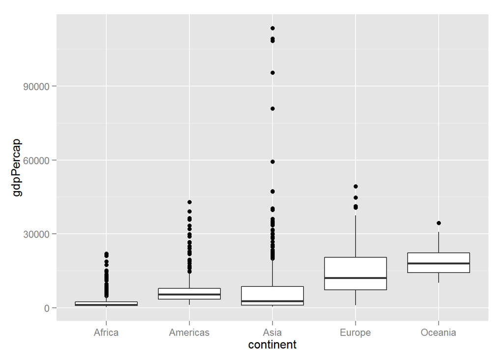

```r
#library(ggplot2)
  #ERROR - That won't work....
#install.packages("ggplot2")
  #Let's try it now...
library(ggplot2)
ggplot(data=gapminderData5Yr.data,aes(group=continent,y=gdpPercap,x=continent)) + geom_boxplot()
```

I can see from the box plot that there are several instances of statistical outliers in each continent’s Per Capita GD distribution.

This will be an important thing to consider when I need to trim the data. If I trim too much from the bottom, I don’t capture a lot of Africa. Perhaps, it would be better to trim the top 5% as opposed to trimming at both ends? How can I do this in such as way that I don’t compromise the integrity of the conclusions I make from the data?

### 3. Compute a trimmed mean of life expectancy for different years.

Considering the 95% confidence level and critical value thresholds, the dangers of “trimming” too much from the data is a concern. Perhaps I should really only trim the outliers that skew *(left or right)* the data? Without manipulating the data more, I cannot determine where the best cut would be. Maybe the top and bottom 1%?

```r
gapminderData5Yr.data %>% group_by(year) %>% summarise(trimmed.mean=mean(lifeExp,trim=0.01))
```

```
## Source: local data frame [12 x 2]
##
##    year trimmed.mean
## 1  1952     49.03365
## 2  1957     51.50178
## 3  1962     53.62026
## 4  1967     55.70098
## 5  1972     57.68435
## 6  1977     59.65452
## 7  1982     61.58685
## 8  1987     63.26868
## 9  1992     64.34149
## 10 1997     65.10934
## 11 2002     65.76776
## 12 2007     67.09170
```

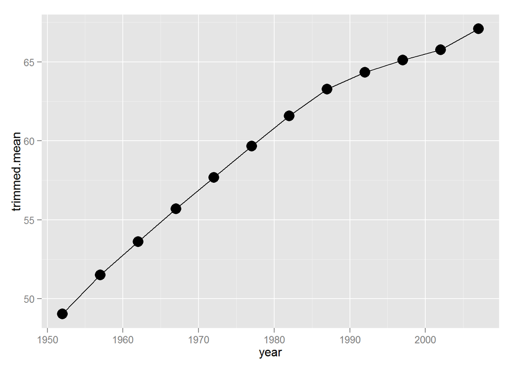

```r
trimmed.lifeExp.means.by.year <- gapminderData5Yr.data %>% group_by(year) %>%

summarise(trimmed.mean = mean(lifeExp,trim=0.01))

ggplot(data=trimmed.lifeExp.means.by.year) + geom_path(aes(x=year,y=trimmed.mean)) +

geom_point(aes(x=year,y=trimmed.mean), size=5)
```

It is obvious from the graph that life expectancy has been increasing since 1950.

```r
67 / (2007-1950)
```

```
## [1] 1.175439
```

```r
(2007-1950) / 12
```

```
## [1] 4.75
```

### 4. How is life expectancy changing over time on different continents?

Okay…I need to “clear” up my messy data…tidyr!

```r
#library(tidyr)
  #ERROR! Do I need the package? Yes!
#install.packages("tidyr")
  #Let's try it now...
library(tidyr)
  #Success!
```

I need to make the data fit into a table that is organized by the categorical variable (x) and the year (y).

I also need it to show the mean life expectancy for each continent at the five year intervals that the data was observed.

First, I need to create a file that contains only these parameters.

```r
mean.lifeExp.longfile = gapminderData5Yr.data %>% group_by(continent,year) %>% summarise(mean = mean(lifeExp))
```

I need to edit the existing variable; the life expectancy mean. I only want 3 decimal spaces.

I have preserved the grouping columns (year) and rows (continents). The spread function lines up the mean with the year.

Now, let see if it tells me what I want to know…

```r
mean.lifeExp.longfile %>% mutate(mean = round(mean,3)) %>% spread(year,mean)
```

```
## Source: local data frame [5 x 13]
##
##   continent   1952   1957   1962   1967   1972   1977   1982   1987   1992
## 1    Africa 39.136 41.266 43.319 45.335 47.451 49.580 51.593 53.345 53.630
## 2  Americas 53.280 55.960 58.399 60.411 62.395 64.392 66.229 68.091 69.568
## 3      Asia 46.314 49.319 51.563 54.664 57.319 59.611 62.618 64.851 66.537
## 4    Europe 64.409 66.703 68.539 69.738 70.775 71.938 72.806 73.642 74.440
## 5   Oceania 69.255 70.295 71.085 71.310 71.910 72.855 74.290 75.320 76.945
## Variables not shown: 1997 (dbl), 2002 (dbl), 2007 (dbl)
```

Looking at the data, I can see that some continents have experienced larger increases in life expectancy than others. Let’s see if we can get a rate of change *(slope; mean change/year change)*. Let’s make a line graph!

First, I need to specify what I want (file)…

```r
lifeExp.mean.by.year.by.continent <- gapminderData5Yr.data %>% group_by(continent,year) %>% summarise(mean = mean(lifeExp))
```

Now, let’s plot it…

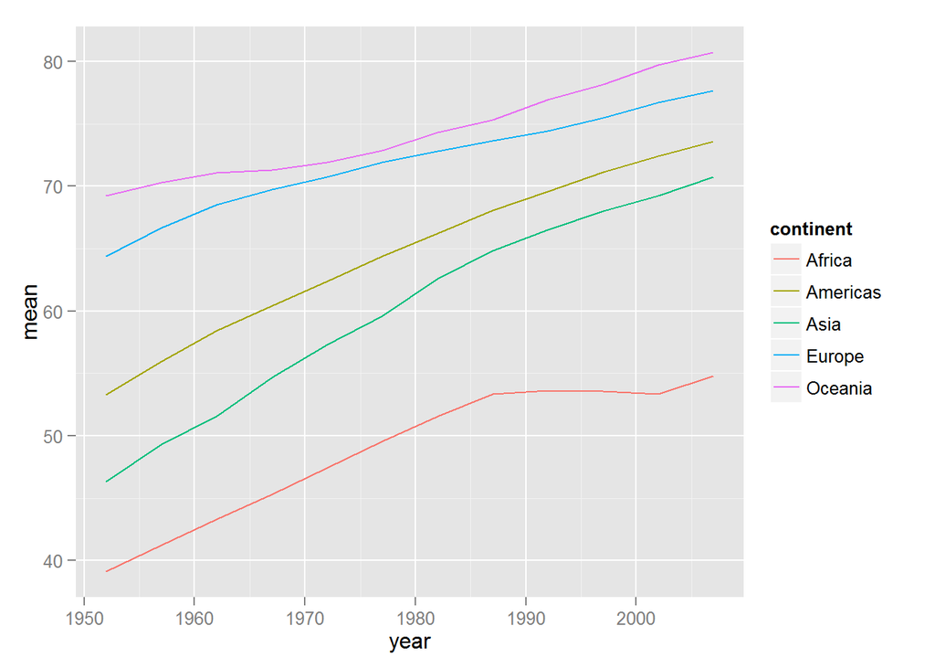

```r
ggplot(data=lifeExp.mean.by.year.by.continent) +geom_line(aes(x=year,y=mean,color=continent))
```

The graph shows that my suspicions are correct. Asia and the Americas are experiencing larger gains in life expectancy. Considering the economic expansion that occurred in BRIC (Brazil, Russia, India, China) countries. Mexico, Venezuela, Argentina, and Peru could be largely responsible for the gains seen in the Americas. China and India may be largely responsible for the gains seen in Asia. Africa was experiencing gains as well until the mid-1980’s and through the 1990’s. There could be various reasons for this; the Ethiopian famine, the AIDS epidemic, Ebola, Rwandan genocide, Kony and his army of child soldiers, Sudan, religious genocide. Europe and Oceania both experienced increases in life expectancy but at a slower rate than the other countries.

### 5. Report the absolute and/or relative abundance of countries with low life expectancy over time by continent.

#### Compute some measure of worldwide life expectancy (mean, median, quintile). Then determine how many countries on each continent have a life expectancy less than this benchmark for each year.

It is reasonable to specify low life expectancy as being 1 sd below the mean. However, considering that many people make choices that are not in their own self-interest (smoking, drinking, illicit drugs) or under their explicit control (poor governance structures and lack of public safeguards and safety nets) regardless of their ability to pay for compensatory healthcare, it may be more reasonable to incorporate 2 SD below the mean as a benchmark. 2 SD below the mean should also capture those most negatively impacted (the indicators of well-being that are important to life expectancy; HH inputs and production functions and trade offs, the role of women in contributing to the HH production function, and political structures that support trade and other HH wage raising activities (farming, trade)).

Let’s try 1 sd first using the following template: new.table <- old.table %>% grouped by year %>% mean calculated for the year, sd for year, if resulting value < (mean-sd), code as 1, otherwise 0.

```r
life.exp.table <- gapminderData5Yr.data %>% group_by(year) %>% mutate(year.mean = mean(lifeExp),year.sd = sd(lifeExp),low.lifeExp = ifelse(lifeExp < year.mean - year.sd,1,0))
```

I have created a new variable; low.lifeExp = ifelse(lifeExp < year.mean - year.sd,1,0).

By taking the mean of low.lifeExp for EACH continent and EACH year, I should get the proportion of countries on each continent that have low life expectancy as I have defined it (1 sd below the mean) for each continent/year pairing. This requires me to make “”new" parameters that contain the information I am interested in. Hence, a new variable…low.lifeExp.by.continent.

```r
low.lifeExp.by.continent = life.exp.table %>% group_by(continent,year) %>% summarise(prop.low.lifeExp = round(mean(low.lifeExp),3))
```

I need to make a table to show the data generated by the previous command… use spread().

**Key** = what I want to turn into column headings **Values** = what I want to be in the table cells.

```r
low.lifeExp.by.continent %>% spread(key = year, value = prop.low.lifeExp)
```

```
## Source: local data frame [5 x 13]
##
##   continent  1952  1957  1962  1967  1972  1977  1982  1987  1992  1997
## 1    Africa 0.327 0.365 0.423 0.442 0.481 0.462 0.500 0.538 0.519 0.558
## 2  Americas 0.000 0.000 0.000 0.000 0.000 0.000 0.000 0.000 0.000 0.000
## 3      Asia 0.121 0.091 0.121 0.121 0.152 0.152 0.121 0.061 0.030 0.030
## 4    Europe 0.000 0.000 0.000 0.000 0.000 0.000 0.000 0.000 0.000 0.000
## 5   Oceania 0.000 0.000 0.000 0.000 0.000 0.000 0.000 0.000 0.000 0.000
## Variables not shown: 2002 (dbl), 2007 (dbl)
```

Just looking at the table, I can see Africa’s rising proportion of low life expectancy instances. I can also see Asia’s declining proportion of low life expectancy; this is expected considering the outsize economic growth fueled by manufacturing and trade *(and the end of the Vietnam War)*.

Just to “hammer” it home, let’s make a graph for those are “table challenged”. FYI, the following graph could be highly effective if I were an NGO trying to get funds for humanitarian relief or economic development…even though the governance structures in many African countries are not conducive to “sustainable” development gains.

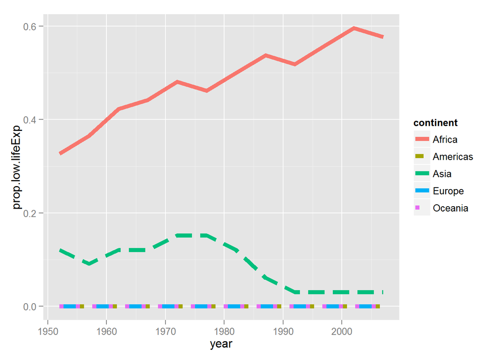

```r
ggplot(data=low.lifeExp.by.continent,aes(x=year,y=prop.low.lifeExp)) + geom_line(aes(color=continent,lty=continent),size=2)
```

### 6. Find countries with intresting stories.

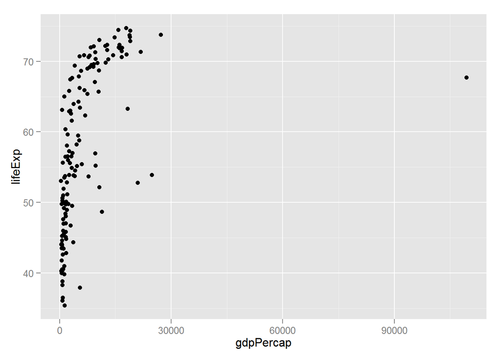

```r
ggplot(gapminderData5Yr.data[gapminderData5Yr.data$year==1972,],aes(x=gdpPercap,y=lifeExp)) + geom_point(aes(label=country))
```

Which country has a Per Capita GDP of over 90,000 units?

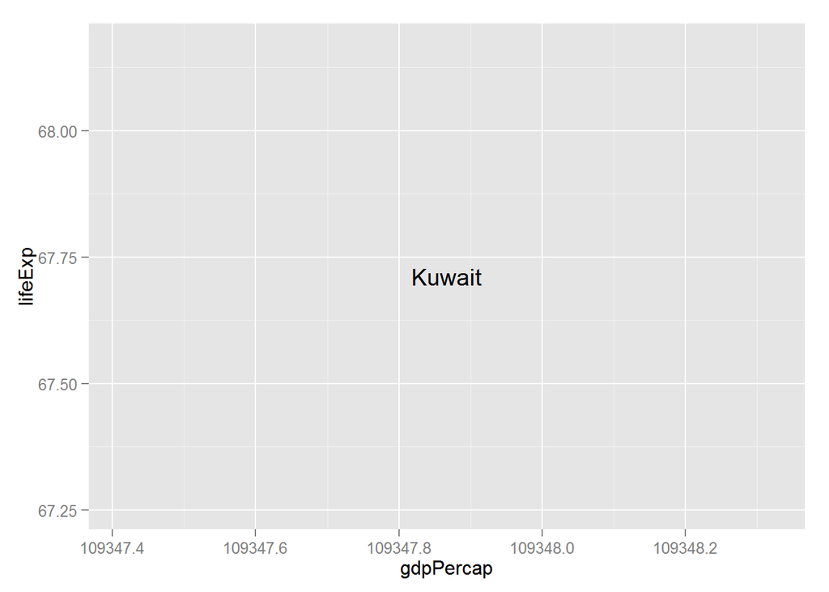

```r
ggplot(gapminderData5Yr.data[gapminderData5Yr.data$year==1972&gapminderData5Yr.data$gdpPercap>90000,],aes(x=gdpPercap,y=lifeExp)) + geom_text(aes(label=country))
```

Kuwait; of course! Wasn’t 1972 getting close to the OPEC Oil Embargo?

I wonder what Kuwait looks like in 1977 after the Oil Embargo?

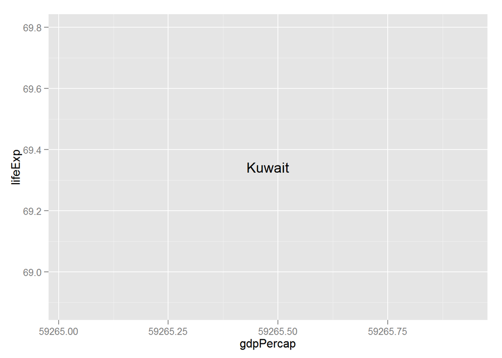

```r
ggplot(gapminderData5Yr.data[gapminderData5Yr.data$year==1977&gapminderData5Yr.data$gdpPercap>40000,],aes(x=gdpPercap,y=lifeExp)) + geom_text(aes(label=country))
```

Interesting…although the Per Capita GDP has fallen significantly, Kuwait still has a much higher relative Per Capita GDP, but looks like it had no declines in life expectancy. Considering that Kuwait is so far away from the normal gdpPercap distribution, it is completely reasonable and logical to make the observation that the declines in Per Capita GDP should have little to no effect on life expectancy. A more interesting question would be to find out the level of Per Capita GDP that has the most profound effect on life expectancy. In the U.S., we speak of a living wage. The term living wage makes many positive assumptions regarding the standard of living of each American regardless of the actual attainability and the elasticity of the local, regional, and national markets to accommodate policy changes that incorporate a living wage. If we were able to pinpoint or “tighten” our understanding of the range of Per Capita GDP that yield the greatest gains in well-being for those who are the worst off, it could be a start to making it happen.

q()